# Unit 7 — Regression Assumptions and Diagnostics

Unit 6 fitted models and read them. This unit asks whether to believe them. Every number a regression prints rests on assumptions about the data, and most of those assumptions are about the **residuals** — so they are checked after the model is fitted, not before.

One rule runs through the whole unit: a check either finds evidence of a problem or finds none. Finding none is not proof that there is none, and a diagnostic report says which.

Four parts:

1. What "controlling for" a third variable means, as a partial correlation.
2. Model 1 of perceived stress, diagnosed end to end.
3. Models 2 and 3, compared with it on the same rows.
4. Independence, on data where it fails.

```python
import math9102 as m9
import numpy as np
import pandas as pd
import pingouin as pg
import statsmodels.api as sm
import statsmodels.formula.api as smf
from scipy import stats

m9.use_house_style()
```

## Part 1 — Controlling for a third variable

The wellbeing survey from Units 4 and 5 carries three scales used all unit:

- `tpstress`, the Perceived Stress Scale;
- `tpcoiss`, the Perceived Control of Internal States Scale;
- `tmarlow`, the Marlowe–Crowne Social Desirability Scale — how inclined a respondent is to answer in the way that looks good.

People who feel in control tend to feel less stressed. But if the people who like to look good also claim calm and claim control, part of that correlation is the habit, not the two things measured. A **partial correlation** removes what the third variable predicts from *both* variables, then correlates what is left.

```python
survey = m9.load_survey()

# The variables first, then the rows complete on those.
model_vars = ["tpstress", "tpcoiss", "tmarlow"]
missing = m9.missingness(survey, model_vars)
print(missing.attrs["summary"])
rows = survey[model_vars].dropna()
```

```
Listwise deletion across these 3 column(s) keeps 423 of 439 rows (loses 16, 3.6%).
```

```python
result = pg.partial_corr(rows, x="tpcoiss", y="tpstress", covar="tmarlow")
result
```

|  | n | r | CI95 | p_val |
| --- | --- | --- | --- | --- |
| pearson | 423 | -0.552179 | [-0.62, -0.48] | 4.735837e-35 |

```python
m9.report_partial_correlation(rows, "tpcoiss", "tpstress", "tmarlow", result,
                              x_label="perceived control", y_label="perceived stress",
                              covar_label="social desirability")
```

The partial correlation between perceived control and perceived stress, controlling for social desirability, was statistically significant: *r*(420) = -.55, *p* < .001, *n* = 423, a large negative association. On the same 423 cases the zero-order correlation was *r* = -.58, so controlling for social desirability moved it 0.03 towards zero. A partial correlation removes social desirability from both variables. It describes association only, and controlling for one measured variable does not rule out others.

The partial correlation is barely different from the zero-order one: social desirability accounts for little of the relationship.

### Partial is not semi-partial

A **semi-partial** correlation removes the third variable from only *one* of the two, so it answers a different question and gives a different number. Removed from stress, it asks whether control goes with the part of stress that social desirability does not predict. Removed from control, it asks whether the part of control that social desirability does not predict goes with stress.

```python
pd.DataFrame({
    "r": [np.corrcoef(rows.tpcoiss, rows.tpstress)[0, 1],
          result["r"].iloc[0],
          pg.partial_corr(rows, "tpcoiss", "tpstress", y_covar="tmarlow")["r"].iloc[0],
          pg.partial_corr(rows, "tpcoiss", "tpstress", x_covar="tmarlow")["r"].iloc[0]],
}, index=["zero-order", "partial: removed from both",
          "semi-partial: removed from stress", "semi-partial: removed from control"])
```

|  | r |
| --- | --- |
| zero-order | -0.581754 |
| partial: removed from both | -0.552179 |
| semi-partial: removed from stress | -0.527449 |
| semi-partial: removed from control | -0.537079 |

**Name the one you computed.** R's `ppcor::spcor.test` computes a semi-partial correlation, and a published report of a "partial correlation" between these two scales quoted its value. The report helper recomputes the partial correlation and refuses anything else:

```python
semi = pg.partial_corr(rows, "tpcoiss", "tpstress", y_covar="tmarlow")
try:
    m9.report_partial_correlation(rows, "tpcoiss", "tpstress", "tmarlow", semi)
except ValueError as refusal:
    print(refusal)
```

```
this result (r = -0.527, n = 423) is not the partial correlation of tpcoiss and tpstress controlling for tmarlow on the complete cases (r = -0.552, n = 423). A semi-partial correlation removes the covariate from one variable only; pass partial_corr(..., covar=...)
```

## Part 2 — Model 1, diagnosed end to end

> **Model 1:** does perceived control predict perceived stress, controlling for social desirability?

### Select the variables, then drop rows

`rows` above already holds Model 1's complete cases. Compare that with dropping every row that has a gap anywhere in the survey's columns:

```python
print(f"rows complete on every column: {len(survey.dropna())} of {len(survey)}")
print(f"rows complete on Model 1's variables: {len(rows)}")
```

```
rows complete on every column: 333 of 439
rows complete on Model 1's variables: 423
```

```python
# Which columns cost the most rows when every column has to be complete?
m9.missingness(survey).head(5)
```

|  | column | missing | percent |
| --- | --- | --- | --- |
| 0 | smokenum | 79 | 18.00 |
| 1 | source | 17 | 3.87 |
| 2 | coo_1 | 13 | 2.96 |
| 3 | mah_1 | 10 | 2.28 |
| 4 | tpcoiss | 9 | 2.05 |

A row missing a variable your model never uses is not missing for your model. Selecting the model's variables first keeps every respondent the model can use.

### How many cases?

Rules of thumb differ, and many circulate without a source. Green (1991) suggests at least fifty plus eight per predictor to test the whole model, and a hundred and four plus one per predictor to test each coefficient — both for a medium-sized relationship. A smaller effect needs more.

```python
m = 2   # predictors in Model 1
print(f"Green's floors: {50 + 8 * m} for the model, {104 + m} for each coefficient; "
      f"Model 1 has {len(rows)}")
```

```
Green's floors: 66 for the model, 106 for each coefficient; Model 1 has 423
```

### Fit, and look at the variables

```python
model1 = smf.ols("tpstress ~ tpcoiss + tmarlow", data=rows).fit()
print(model1.summary())
```

```
                            OLS Regression Results
==============================================================================
Dep. Variable:               tpstress   R-squared:                       0.342
Model:                            OLS   Adj. R-squared:                  0.339
Method:                 Least Squares   F-statistic:                     109.3
Date:                Mon, 02 Nov 2026   Prob (F-statistic):           5.92e-39
Time:                        08:34:32   Log-Likelihood:                -1258.4
No. Observations:                 423   AIC:                             2523.
Df Residuals:                     420   BIC:                             2535.
Df Model:                           2
Covariance Type:            nonrobust
==============================================================================
                 coef    std err          t      P>|t|      [0.025      0.975]
------------------------------------------------------------------------------
Intercept     44.3488      1.222     36.283      0.000      41.946      46.751
tpcoiss       -0.2741      0.020    -13.573      0.000      -0.314      -0.234
tmarlow       -0.1913      0.120     -1.590      0.113      -0.428       0.045
==============================================================================
Omnibus:                       13.672   Durbin-Watson:                   1.827
Prob(Omnibus):                  0.001   Jarque-Bera (JB):               27.529
Skew:                          -0.096   Prob(JB):                     1.05e-06
Kurtosis:                       4.235   Cond. No.                         328.
==============================================================================

Notes:
[1] Standard Errors assume that the covariance matrix of the errors is correctly specified.
```

```python
# Non-zero variance: every variable in the model varies.
rows.var()
```

```
tpstress     34.242524
tpcoiss     144.043707
tmarlow       4.061757
dtype: float64
```

Nothing above is believed yet. The rest of this part checks it.

### Residuals, visually first

The assumptions that matter most are about the residuals: the part of each score the model did not predict. The four standard plots, on Model 1 alone:

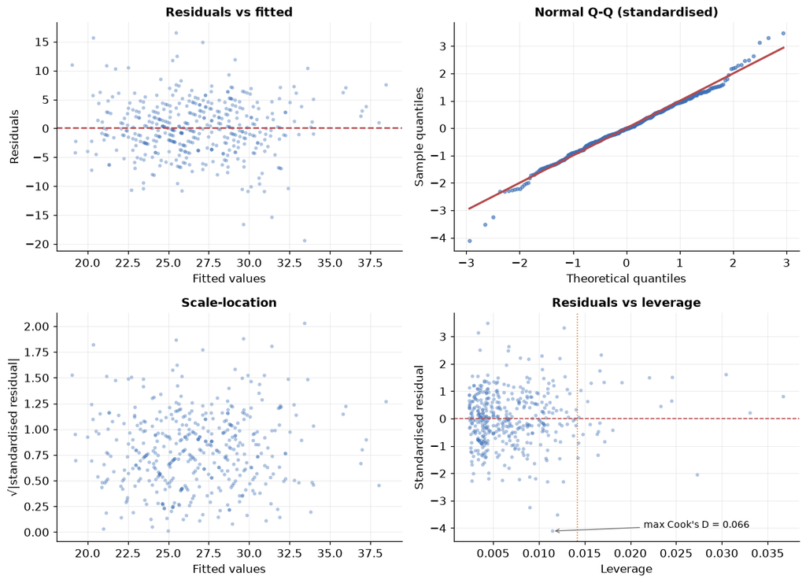

```python
m9.residual_panel(model1);
```

Read them in order:

- **Residuals against fitted values:** a shapeless band about zero — no curve, no funnel.
- **Q–Q plot:** close to the line through the middle; both tails stray a little.
- **Scale–location:** a flat band — no sign that the spread changes along the line.
- **Residuals against leverage:** no case is both far out in the predictors and far from the line.

### Normality of the residuals: what the test adds

```python
m9.check_normality(model1)
```

```
[  --] Normality of residuals: Shapiro-Wilk W = 0.988, p = 0.0014 on 423 residuals. The test found a departure, but at this sample size it detects departures too small to affect the regression, so the Q-Q plot decides the question.
```

Shapiro–Wilk is significant. With four hundred residuals it detects departures far too small to matter, so its flag is left empty: the Q–Q plot is the evidence. The outcome itself does not need to be normal — only the error around the line.

### Standardised residuals

A standardised residual divides each residual by **its own** standard error, *s*√(1 − *h*ᵢᵢ), which shrinks for a case far out in the predictors. Dividing every residual by one standard deviation ignores that.

```python
infl = model1.get_influence()
standardised = infl.resid_studentized_internal
naive = model1.resid / model1.resid.std()
print(f"largest leverage: {infl.hat_matrix_diag.max():.3f}")
pd.DataFrame({"standardised": [standardised.min(), standardised.max()],
              "e / sd(e)": [naive.min(), naive.max()]}, index=["min", "max"])
```

```
largest leverage: 0.037
```

|  | standardised | e / sd(e) |
| --- | --- | --- |
| min | -4.110783 | -4.096792 |
| max | 3.478567 | 3.479125 |

Here the two ranges are close. Even the largest leverage, printed above the table, leaves √(1 − *h*ᵢᵢ) near one, so no case has leverage high enough to separate the two. With one that did, the shortcut would understate exactly the residual that matters.

```python
print(f"beyond ±1.96: {(np.abs(standardised) > 1.96).mean():.1%} (about 5% expected)")
print(f"beyond ±3.29: {(np.abs(standardised) > 3.29).sum()} cases")
```

```
beyond ±1.96: 5.9% (about 5% expected)
beyond ±3.29: 4 cases
```

### The Bonferroni outlier test

This test uses **studentised** residuals. A studentised residual is a standardised one whose *s* comes from the model fitted without that case, so a case far from the line cannot inflate its own denominator and hide. The most extreme is tested, with its *p*-value multiplied by the number of cases — because it was picked as the largest.

```python
tests = model1.outlier_test()
tests.sort_values("student_resid", key=abs, ascending=False).head(3)
```

|  | student_resid | unadj_p | bonf(p) |
| --- | --- | --- | --- |
| 54 | -4.191064 | 0.000034 | 0.014334 |
| 55 | -3.572781 | 0.000394 | 0.166769 |
| 17 | 3.525582 | 0.000469 | 0.198461 |

The index is the row label in the survey, so the case can be looked up:

```python
# The most extreme case: the largest studentised residual in size.
worst = tests["student_resid"].abs().idxmax()
scales = ["tpstress", "tpcoiss", "tmarlow"]
pd.DataFrame({f"row {worst}": survey.loc[worst, scales],
              "lowest": survey[scales].min(), "median": survey[scales].median(),
              "highest": survey[scales].max()})
```

|  | row 54 | lowest | median | highest |
| --- | --- | --- | --- | --- |
| tpstress | 14.0 | 12.0 | 26.0 | 46.0 |
| tpcoiss | 37.0 | 20.0 | 62.0 | 88.0 |
| tmarlow | 4.0 | 0.0 | 5.0 | 10.0 |

Nothing marks these scores as an entry error: each is a whole number inside the range the survey's respondents gave, and none sits at either end of it. The model fits this respondent badly; nothing in the data says the answers are wrong.

### Influence: Cook's distance and standardised DFBETAS

An outlier matters when it moves the model. **Cook's distance** measures how far all the fitted values move when a case is left out; **standardised DFBETAS** measure how far each coefficient moves, in its own standard errors. Both use 1 as the usual convention, and the DFBETAS threshold belongs to the standardised version only. Conventions differ: Belsley, Kuh and Welsch's size-adjusted cut-off for DFBETAS, 2/√*n*, shrinks as the sample grows, and at this size it lists many cases. Treat such a list as cases to look at, not as an alarm.

```python
m9.check_influence(model1, top=5)
```

|  | case | cooks_d | leverage | std_residual | max_abs_dfbetas | flag |
| --- | --- | --- | --- | --- | --- | --- |
| 0 | 54 | 0.06554 | 0.01150 | -4.111 | 0.427 | \|resid\|>3.29 |
| 1 | 55 | 0.05044 | 0.01204 | -3.524 | 0.303 | \|resid\|>3.29 |
| 2 | 138 | 0.04719 | 0.01277 | 3.308 | 0.343 | \|resid\|>3.29 |
| 3 | 5 | 0.03960 | 0.02732 | -2.057 | 0.295 | leverage>0.014 |
| 4 | 11 | 0.03216 | 0.00902 | -3.255 | 0.264 |  |

```python
k = len(model1.params)   # coefficients, counting the intercept
cut = 2 * k / len(rows)
print(f"2k/n = {cut:.3f}: {(infl.hat_matrix_diag > cut).sum()} cases above it")
```

```
2k/n = 0.014: 26 cases above it
```

Nothing comes near either alarm. Many cases have leverage above 2*k*/*n*, twice the average leverage, where *k* counts the model's coefficients with the intercept. They sit further out in the predictors than most, and none of them moves the line much: the one the table above flags for leverage has a Cook's distance far below 1.

### What to do with an outlier: run it twice

```python
without = smf.ols("tpstress ~ tpcoiss + tmarlow", data=rows.drop(index=worst)).fit()
pd.DataFrame({"with": model1.params, "without": without.params,
              "p with": model1.pvalues, "p without": without.pvalues})
```

|  | with | without | p with | p without |
| --- | --- | --- | --- | --- |
| Intercept | 44.348833 | 44.860422 | 1.589548e-131 | 6.023331e-135 |
| tpcoiss | -0.274141 | -0.281684 | 4.735837e-35 | 1.781926e-37 |
| tmarlow | -0.191268 | -0.192840 | 1.125348e-01 | 1.028829e-01 |

```python
print(f"R squared with: {model1.rsquared:.3f}, without: {without.rsquared:.3f}")
```

```
R squared with: 0.342, without: 0.362
```

The coefficients barely move and no conclusion changes, so the case stays and both fits can be reported. *R²* rises without it — which is why a rule that deletes every badly fitted case makes a model look better than it is.

**Excluding a group is a different decision.** Cases outside the population your question is about — students who never sat an exam, in a model of exam grades — can be set aside, but before fitting, with the reason stated and the number shown. That is a decision about the question. Dropping cases because the model fits them badly is a decision about the answer, and it is never yours to make.

### Constant variance

```python
m9.check_homoscedasticity(model1)
```

```
[  ok] Homoscedasticity: Breusch-Pagan (Koenker) LM = 3.335 on 2 df, p = 0.1887. No evidence that the residual variance changes with the predictors; read the residuals-against-fitted plot as well.
```

This is Koenker's version of the Breusch–Pagan test, which does not assume normal residuals. R's `performance` package runs the original version on the fitted values; it gives a different *p*-value, and neither finds evidence of changing variance:

```python
from statsmodels.stats.diagnostic import het_breuschpagan

original = het_breuschpagan(model1.resid, sm.add_constant(model1.fittedvalues), robust=False)
print(f"original Breusch–Pagan on the fitted values: LM = {original[0]:.2f}, p = {original[1]:.3f}")
```

```
original Breusch–Pagan on the fitted values: LM = 3.24, p = 0.072
```

No evidence is not proof. The residuals-against-fitted plot showed no funnel, and that is the second half of the evidence.

### Where variance does change: a remedy

Professors' salaries, against years since the PhD. The plots first:

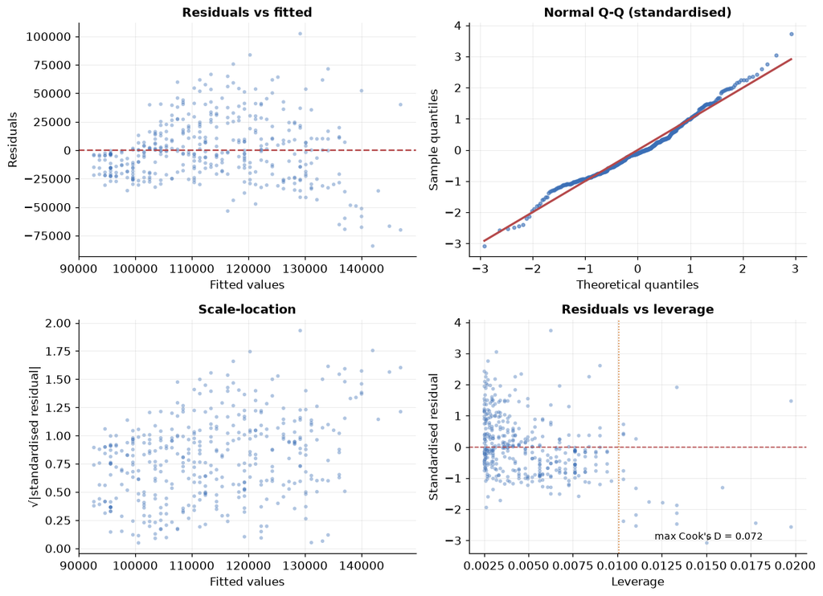

```python
salaries = m9.load_salaries()
ols = smf.ols("salary ~ yrs_since_phd", data=salaries).fit()
m9.residual_panel(ols);
```

The residuals fan out as the fitted salary rises, and the scale–location points climb from left to right: a funnel. The test agrees:

```python
m9.check_homoscedasticity(ols)
```

```
[warn] Homoscedasticity: Breusch-Pagan (Koenker) LM = 50.787 on 1 df, p < 0.0001. The residual variance changes with the predictors, so the ordinary standard errors are unreliable; consider robust (HC3) standard errors.
```

The residuals also bend: above zero in the middle of the fitted range and below it at both ends, so a straight line in years since the PhD misses a curve as well. That is a question about the model's form, not its standard errors, and neither remedy below answers it. This section keeps to the funnel.

```python
hc3 = smf.ols("salary ~ yrs_since_phd", data=salaries).fit(cov_type="HC3")
pd.DataFrame({"b": ols.params, "SE, OLS": ols.bse, "SE, HC3": hc3.bse})
```

|  | b | SE, OLS | SE, HC3 |
| --- | --- | --- | --- |
| Intercept | 91718.685447 | 2765.792261 | 2485.365605 |
| yrs_since_phd | 985.342124 | 107.365126 | 127.593497 |

**Robust (HC3) standard errors** repair the reported standard errors and leave the slope, and the question, unchanged. Heteroscedasticity never biased the slope: it made its standard error wrong.

A transformation changes the question instead. With log salary as the outcome, the slope is a proportion:

```
each year since the PhD goes with about 0.86% more salary
```

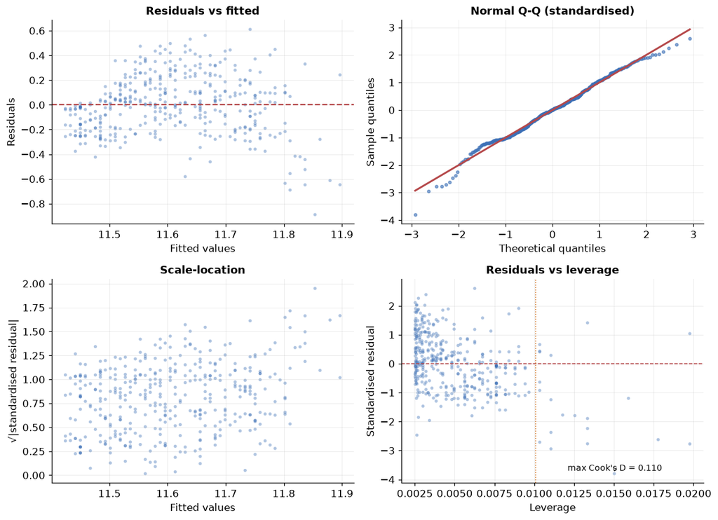

```python
logged = smf.ols("np.log(salary) ~ yrs_since_phd", data=salaries).fit()
print(f"each year since the PhD goes with about "
      f"{np.exp(logged.params['yrs_since_phd']) - 1:.2%} more salary")
m9.residual_panel(logged);
```

```python
m9.check_homoscedasticity(logged)
```

```
[warn] Homoscedasticity: Breusch-Pagan (Koenker) LM = 38.245 on 1 df, p < 0.0001. The residual variance changes with the predictors, so the ordinary standard errors are unreliable; consider robust (HC3) standard errors.
```

And here the log does not even fix the funnel. Its scale–location points still climb, and its Breusch–Pagan statistic, though smaller than the raw model's, still finds the variance changing. Check the residuals of the model you report, not the one you meant to fit.

### Collinearity

```python
m9.check_collinearity(model1)
```

|  | predictor | df | VIF | tolerance | GVIF | concern |
| --- | --- | --- | --- | --- | --- | --- |
| 0 | tpcoiss | 1 | 1.096 | 0.912 | 1.096 | ok |
| 1 | tmarlow | 1 | 1.096 | 0.912 | 1.096 | ok |

One row per term. With two predictors the two VIFs are equal by construction. Both are close to one: control and social desirability barely overlap.

### The diagnostic report

The paragraph is generated after fitting. It needs **your** reading of the plots, in one sentence, because the plots are the primary evidence and no function can read them for you. Independence is described from the design, or declared not examined.

```python
m9.report_diagnostics(
    model1,
    plots="The residuals scatter evenly about zero with no curve or funnel, "
          "and the Q-Q plot follows the line except in the tails",
    design="each respondent answered once, and the data record no grouping",
    predictor_labels={"tpcoiss": "perceived control", "tmarlow": "social desirability"},
)
```

The residuals scatter evenly about zero with no curve or funnel, and the Q-Q plot follows the line except in the tails. Shapiro–Wilk *W* = .988, *p* = .001 on 423 residuals; the test found a departure, but at this sample size it detects departures too small to affect the model, so the plots are the evidence. Standardised residuals ranged from -4.11 to 3.48; 4 cases lay beyond ±3.29, and 5.9% beyond ±1.96, against the 5% expected. The most extreme case (row 54) gave a Bonferroni-adjusted outlier test *p* = .014, so it is an outlier by that test. The largest Cook's distance was 0.066 (none above 1), and the largest standardised DFBETAS 0.43 (none above 1); 26 cases had leverage above 2*k*/*n* = .014. A Breusch–Pagan test (Koenker's version) gave χ²(2) = 3.33, *p* = .189: no evidence that the residual variance changes with the predictors. The largest variance inflation factor was 1.10 (perceived control), tolerance .91. On independence: each respondent answered once, and the data record no grouping.

It reports each check as what it found. It never says an assumption was "confirmed" or "met".

## Part 3 — Models 2 and 3

> **Model 2:** adds optimism (`toptim`). **Model 3:** adds sex as well.

Compared models must be fitted on the same rows. Select every variable any of the three uses, and drop missing rows once:

```python
common = survey[["tpstress", "tpcoiss", "tmarlow", "toptim", "sex"]].dropna()
print(f"{len(common)} rows, against Model 1's own {len(rows)}")
rows.index.difference(common.index)
```

```
422 rows, against Model 1's own 423
```

```
Index([39], dtype='int64')
```

One respondent has no optimism score. All three models are refitted on the shared rows:

```python
m1 = smf.ols("tpstress ~ tpcoiss + tmarlow", data=common).fit()
m2 = smf.ols("tpstress ~ tpcoiss + tmarlow + toptim", data=common).fit()
m3 = smf.ols("tpstress ~ tpcoiss + tmarlow + toptim + sex", data=common).fit()

labels = {"tpcoiss": "perceived control", "tmarlow": "social desirability",
          "toptim": "optimism", "sex[T.MALES]": "sex (male against female)"}
m9.report_model_comparison(m1, m2, predictor_labels=labels)
```

Adding optimism to the model with perceived control and social desirability (both fitted on the same *N* = 422 rows) changed *R²* by .039, from .342 to .381. This was a statistically significant improvement, *F*(1, 418) = 26.18, *p* < .001.

```python
m9.report_model_comparison(m2, m3, predictor_labels=labels)
```

Adding sex (male against female) to the model with perceived control, social desirability and optimism (both fitted on the same *N* = 422 rows) changed *R²* by .013, from .381 to .394. This was a statistically significant improvement, *F*(1, 417) = 9.02, *p* = .003.

```python
pd.concat({name: m9.check_collinearity(m).set_index("predictor")["VIF"]
           for name, m in {"Model 1": m1, "Model 2": m2, "Model 3": m3}.items()}, axis=1)
```

| predictor | Model 1 | Model 2 | Model 3 |
| --- | --- | --- | --- |
| tpcoiss | 1.096 | 1.472 | 1.514 |
| tmarlow | 1.096 | 1.097 | 1.117 |
| toptim | NaN | 1.365 | 1.376 |
| sex | NaN | NaN | 1.037 |

Optimism and control overlap, so their VIFs rise when optimism comes in — far below any convention for concern.

```python
m9.report_regression(m3, outcome_label="perceived stress", predictor_labels=labels)
```

A linear regression model was fitted to predict perceived stress from 4 predictor terms (*N* = 422). The overall model was statistically significant, *F*(4, 417) = 67.70, *p* < .001. *R²* = .394: the model accounts for 39.4% of the variance in perceived stress in this sample, large by Cohen's convention for *R²* (adjusted *R²* = .388).

Coefficients, with 95% confidence intervals: sex (male against female), *b* = -1.379 [-2.282, -0.476], *p* = .003; perceived control, *b* = -0.203 [-0.248, -0.159], *p* < .001; social desirability, *b* = -0.259 [-0.489, -0.029], *p* = .027; optimism, *b* = -0.322 [-0.438, -0.205], *p* < .001. Each coefficient is read holding the other predictors constant.

Fitted equation: perceived stress = 48.130 - 1.379 × sex (male against female) - 0.203 × perceived control - 0.259 × social desirability - 0.322 × optimism

The model describes an association in these data. It does not establish that any of these predictors causes perceived stress.

**An extra predictor, not a moderator.** Model 3 moves the line up or down for one sex. It does not let the effect of control differ by sex: that would need the product term, `tpcoiss * sex`. "Sex moderates the relationship" cannot be claimed from Model 3.

Model 3 is diagnosed the same way as Model 1:

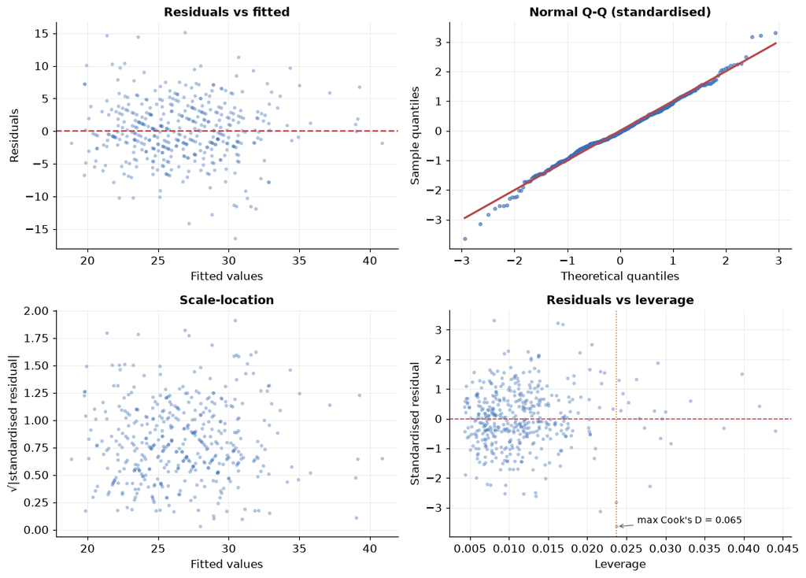

```python
m9.residual_panel(m3);
```

```python
m9.report_diagnostics(
    m3,
    plots="The residual plots show no curve or funnel, and the Q-Q plot "
          "strays only in the tails",
    design="each respondent answered once, and the data record no grouping",
    predictor_labels=labels,
)
```

The residual plots show no curve or funnel, and the Q-Q plot strays only in the tails. Shapiro–Wilk *W* = .992, *p* = .030 on 422 residuals; the test found a departure, but at this sample size it detects departures too small to affect the model, so the plots are the evidence. Standardised residuals ranged from -3.64 to 3.31; 2 cases lay beyond ±3.29, and 6.2% beyond ±1.96, against the 5% expected. The most extreme case (row 54) gave a Bonferroni-adjusted outlier test *p* = .105. The largest Cook's distance was 0.065 (none above 1), and the largest standardised DFBETAS 0.49 (none above 1); 21 cases had leverage above 2*k*/*n* = .024. A Breusch–Pagan test (Koenker's version) gave χ²(4) = 9.49, *p* = .050: at the conventional threshold, which is no verdict either way; the residual plot, and a refit with robust standard errors, are the evidence. The largest variance inflation factor was 1.51 (perceived control), tolerance .66. On independence: each respondent answered once, and the data record no grouping.

Read the Breusch–Pagan result here closely: its *p* reports as .050, on the conventional threshold itself, and the paragraph says so and gives no verdict. A test this close to the line is not evidence either way, and certainly not a confirmation. The plot shows no funnel. The way to settle whether it matters is to refit with robust standard errors and compare:

```python
robust3 = smf.ols("tpstress ~ tpcoiss + tmarlow + toptim + sex", data=common).fit(cov_type="HC3")
pd.DataFrame({"SE, OLS": m3.bse, "SE, HC3": robust3.bse,
              "p, OLS": m3.pvalues, "p, HC3": robust3.pvalues})
```

|  | SE, OLS | SE, HC3 | p, OLS | p, HC3 |
| --- | --- | --- | --- | --- |
| Intercept | 1.350727 | 1.390072 | 1.304004e-128 | 1.102046e-262 |
| sex[T.MALES] | 0.459368 | 0.469131 | 2.837855e-03 | 3.280888e-03 |
| tpcoiss | 0.022864 | 0.028512 | 1.737349e-17 | 9.575071e-13 |
| tmarlow | 0.116911 | 0.125952 | 2.735363e-02 | 3.985072e-02 |
| toptim | 0.059330 | 0.063308 | 1.014742e-07 | 3.801371e-07 |

Every robust standard error is larger, perceived control's the most, and every coefficient that was significant still is. Here the borderline test changes no conclusion; report that you checked, and how.

### Collinearity that is not a problem: a categorical block

A categorical predictor's dummies are checked as one block. The Youth Cohort's school type has six categories, and the alphabetical one, which the formula makes the reference, is the smallest:

```python
youth = m9.load_youthcohort().dropna(subset=["s1pared", "pcschtype"])
youth["pcschtype"].value_counts()
```

```
pcschtype
Comprehensive 18        6665
Comprehensive 16        4136
Independent             1196
Grammar                  715
Modern                   373
CTC/Other maintained     116
Name: count, dtype: int64
```

With that reference, most of the dummies look collinear on their own:

```python
from statsmodels.stats.outliers_influence import variance_inflation_factor

school = smf.ols("gcsepts ~ s1pared + pcschtype", data=youth).fit()
pd.Series([variance_inflation_factor(school.model.exog, i)
           for i in range(1, school.model.exog.shape[1])],
          index=school.model.exog_names[1:], name="VIF per dummy")
```

```
s1pared[T.At least one parent with degree]     1.723335
s1pared[T.Neither parent with A-level]         1.694680
pcschtype[T.Comprehensive 16]                 25.176033
pcschtype[T.Comprehensive 18]                 28.945195
pcschtype[T.Grammar]                           6.794568
pcschtype[T.Independent]                      10.347760
pcschtype[T.Modern]                            4.096941
Name: VIF per dummy, dtype: float64
```

```python
m9.check_collinearity(school)
```

|  | predictor | df | VIF | tolerance | GVIF | concern |
| --- | --- | --- | --- | --- | --- | --- |
| 0 | s1pared | 2 | 1.040 | 0.961 | 1.083 | ok |
| 1 | pcschtype | 5 | 1.016 | 0.984 | 1.083 | ok |

The generalised VIF (Fox and Monette, 1992) gives one number per term, and it does not depend on the reference. Refit with the largest school type as the reference, and the block's row reads the same:

```python
# Categories in order of size, so the first, the reference, is the largest.
order = youth["pcschtype"].value_counts().index
reordered = youth.assign(pcschtype=pd.Categorical(youth["pcschtype"], categories=order))
largest = smf.ols("gcsepts ~ s1pared + pcschtype", data=reordered).fit()
m9.check_collinearity(largest)
```

|  | predictor | df | VIF | tolerance | GVIF | concern |
| --- | --- | --- | --- | --- | --- | --- |
| 0 | s1pared | 2 | 1.040 | 0.961 | 1.083 | ok |
| 1 | pcschtype | 5 | 1.016 | 0.984 | 1.083 | ok |

The per-dummy numbers measured how small the reference group is, not collinearity.

## Part 4 — Independence, where it fails

Independence is a property of how the data were collected, and no residual plot can show it on data like the survey's. On data where the grouping is recorded, the residuals can show it. Unit 6's pupils sit in sixty-five schools:

```python
regression = m9.load_regression()
pupils = smf.ols("normexam ~ standlrt", data=regression).fit()
by_school = regression.assign(residual=pupils.resid)

m9.icc(by_school, "residual", "school")
```

```
{'icc': 0.128372037129347,
 'n_clusters': 65,
 'mean_cluster_size': 62.44615384615385,
 'design_effect': 8.887967942994031}
```

```python
means = by_school.groupby("school")["residual"].agg(["mean", "sem"])
off = ((means["mean"] - 1.96 * means["sem"] > 0) | (means["mean"] + 1.96 * means["sem"] < 0))
print(f"{off.sum()} of {len(means)} schools have a mean residual whose interval misses zero")
```

```
31 of 65 schools have a mean residual whose interval misses zero
```

If pupils were independent, nearly every school's interval would cross zero. Pupils in one school are more alike than the model assumes, so its standard errors are too small. By how much depends on what is estimated. The design effect printed above is for a **mean**: it is how many times larger a mean's variance is than in a sample of as many independent pupils. A slope is inflated by a different amount, which depends on how far its predictor also clusters by school. Cluster-robust standard errors measure it directly:

```python
clustered = smf.ols("normexam ~ standlrt", data=regression).fit(
    cov_type="cluster", cov_kwds={"groups": regression["school"]})
(clustered.bse / pupils.bse).rename("how much wider, clustered")
```

```
Intercept    3.072388
standlrt     1.842789
Name: how much wider, clustered, dtype: float64
```

**For the survey there is no such grouping to check.** Each person answered once, and the data record no household, class or site. That is all the design tells you. Say so in the report — or say independence was not examined — and never write that it was "met".

## What to take from this unit

- A **partial** correlation removes the third variable from both variables; a **semi-partial** from one. Name the one you computed.
- Select the model's variables, then drop rows — and show the cost.
- The assumptions are about different things: linearity about the mean, normality and constant variance about the **residuals**, independence about the **design**. The outcome need not be normal.
- Read the residual plots first. At hundreds of cases a significant normality test is not a verdict.
- A standardised residual divides by *s*√(1 − *h*ᵢᵢ). Outliers, leverage points and influential cases are different things; Cook's distance and standardised DFBETAS measure influence.
- Run an outlier twice. Never delete a real case for being unusual; exclude a group only if it is outside the question's population, decided before fitting and stated.
- Heteroscedasticity misstates standard errors and collinearity inflates them; neither biases the coefficients. Robust standard errors repair the first.
- Check a categorical predictor's collinearity as one block.
- A diagnostic report says what each check found, and never more.

## Exercise

`exercise.md` takes the sleep study: count what dropping rows costs, recode a rating stored as text, fit and diagnose two models of sleepiness, generate the report, and criticise a regression write-up.